# Project: Investigate a Dataset - TMDb Movies

- Introduction
- Data Wrangling
- Exploratory Data Analysis
- Conclusions

## Introduction

### Dataset Description

> This data set contains information about 10,000 movies collected from The Movie Database (TMDb), including user ratings and revenue. Certain columns, like ‘cast’ and ‘genres’, contain multiple values separated by pipe (|) characters. There are some odd characters in the ‘cast’ column. Don’t worry about cleaning them. You can leave them as is. The final two columns ending with “_adj” show the budget and revenue of the associated movie in terms of 2010 dollars, accounting for inflation over time.

```python
import pandas as pd
import numpy as np
import matplotlib.pyplot as plt
import seaborn as sns

%matplotlib inline
```

## Data Wrangling

### Load the dataset

```python
df = pd.read_csv('Database_TMDb_movie_data/tmdb-movies.csv')
```

### Display the first few rows of the dataframe

```python
print("First few rows of the dataframe:")
df.head()
```

```
First few rows of the dataframe:
```

[output not shown]

### Check the size of the dataframe

```python
print("\nSize of the dataframe (rows, columns):", df.shape)
```

```
Size of the dataframe (rows, columns): (10866, 21)
```

### Inspect data types

```python
print("\nData types of columns:")
print(df.dtypes)
```

```
Data types of columns:
id                        int64
imdb_id                  object
popularity              float64
budget                    int64
revenue                   int64
original_title           object
cast                     object
homepage                 object
director                 object
tagline                  object
keywords                 object
overview                 object
runtime                   int64
genres                   object
production_companies     object
release_date             object
vote_count                int64
vote_average            float64
release_year              int64
budget_adj              float64
revenue_adj             float64
dtype: object
```

### Check for missing values

```python
print("\nMissing values:")
df.isnull().sum()
```

```
Missing values:
```

[output not shown]

### Statistical summary of the dataset

```python
print("\nStatistical summary of the dataset:")
print(df.describe())
```

```
Statistical summary of the dataset:
                  id    popularity        budget       revenue       runtime  \
count   10866.000000  10866.000000  1.086600e+04  1.086600e+04  10866.000000
mean    66064.177434      0.646441  1.462570e+07  3.982332e+07    102.070863
std     92130.136561      1.000185  3.091321e+07  1.170035e+08     31.381405
min         5.000000      0.000065  0.000000e+00  0.000000e+00      0.000000
25%     10596.250000      0.207583  0.000000e+00  0.000000e+00     90.000000
50%     20669.000000      0.383856  0.000000e+00  0.000000e+00     99.000000
75%     75610.000000      0.713817  1.500000e+07  2.400000e+07    111.000000
max    417859.000000     32.985763  4.250000e+08  2.781506e+09    900.000000

         vote_count  vote_average  release_year    budget_adj   revenue_adj
count  10866.000000  10866.000000  10866.000000  1.086600e+04  1.086600e+04
mean     217.389748      5.974922   2001.322658  1.755104e+07  5.136436e+07
std      575.619058      0.935142     12.812941  3.430616e+07  1.446325e+08
min       10.000000      1.500000   1960.000000  0.000000e+00  0.000000e+00
25%       17.000000      5.400000   1995.000000  0.000000e+00  0.000000e+00
50%       38.000000      6.000000   2006.000000  0.000000e+00  0.000000e+00
75%      145.750000      6.600000   2011.000000  2.085325e+07  3.369710e+07
max     9767.000000      9.200000   2015.000000  4.250000e+08  2.827124e+09
```

### Data Cleaning

```python
# After discussing the structure of the data and any problems that need to be
#   cleaned, perform those cleaning steps in the second part of this section.
# Drop rows with missing values
df.dropna(inplace=True)

# Check the shape of the dataframe after dropping missing values
df.shape
```

```
(1992, 21)
```

## Exploratory Data Analysis

### Question 1: How does the adjusted revenue of movies vary with their adjusted budget?

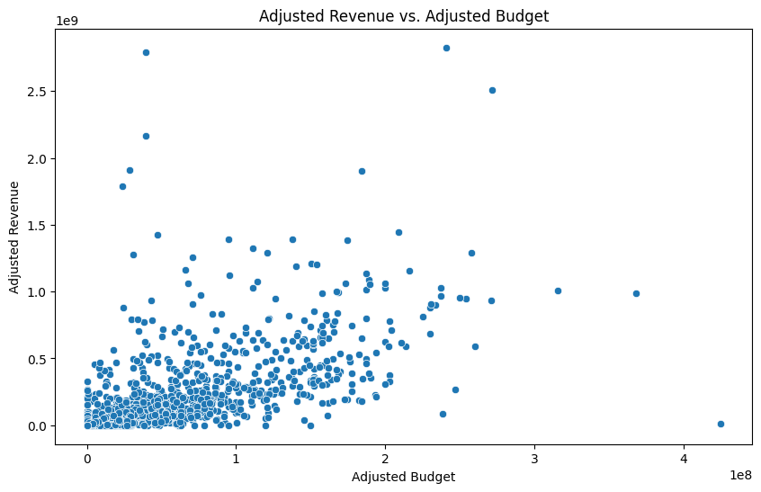

```python
# Scatter plot of revenue vs. budget
plt.figure(figsize=(10, 6))
sns.scatterplot(x='budget_adj', y='revenue_adj', data=df)
plt.title('Adjusted Revenue vs. Adjusted Budget')
plt.xlabel('Adjusted Budget')
plt.ylabel('Adjusted Revenue')
plt.show()
```

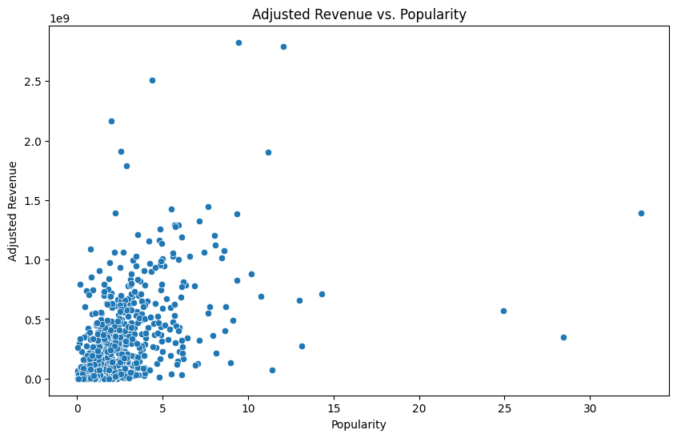

```python
# Scatter plot of revenue vs. popularity
plt.figure(figsize=(10, 6))
sns.scatterplot(x='popularity', y='revenue_adj', data=df)
plt.title('Adjusted Revenue vs. Popularity')
plt.xlabel('Popularity')
plt.ylabel('Adjusted Revenue')
plt.show()
```

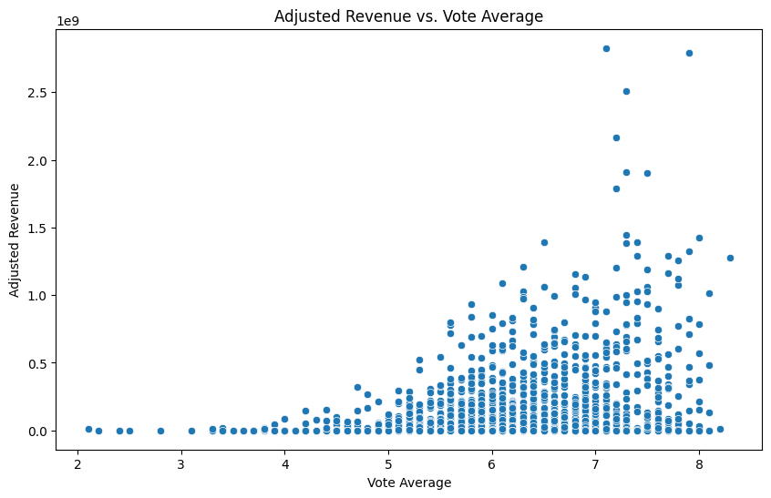

```python
# Scatter plot of revenue vs. vote average
plt.figure(figsize=(10, 6))
sns.scatterplot(x='vote_average', y='revenue_adj', data=df)
plt.title('Adjusted Revenue vs. Vote Average')
plt.xlabel('Vote Average')
plt.ylabel('Adjusted Revenue')
plt.show()
```

### Question 5: What is the distribution of adjusted movie revenue like?

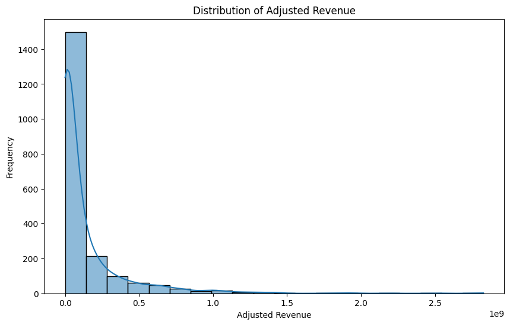

```python
# Plotting distribution of revenue_adj
plt.figure(figsize=(10, 6))
sns.histplot(df['revenue_adj'], bins=20, kde=True)
plt.title('Distribution of Adjusted Revenue')
plt.xlabel('Adjusted Revenue')
plt.ylabel('Frequency')
plt.show()
```

### Question 5: What is the trend in adjusted revenue over release years?

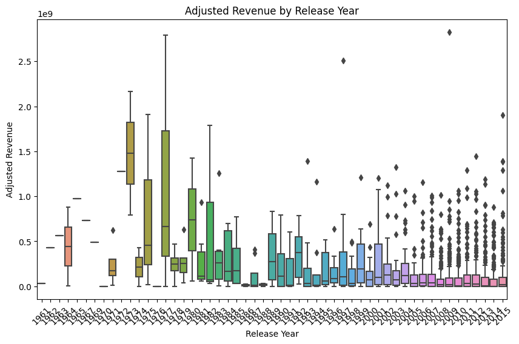

```python
# The relationship between revenue_adj and release_year
plt.figure(figsize=(10, 6))
sns.boxplot(x='release_year', y='revenue_adj', data=df)
plt.title('Adjusted Revenue by Release Year')
plt.xlabel('Release Year')
plt.ylabel('Adjusted Revenue')
plt.xticks(rotation=45)
plt.show()
```

### Question 6: How does the popularity of movies vary by release month?

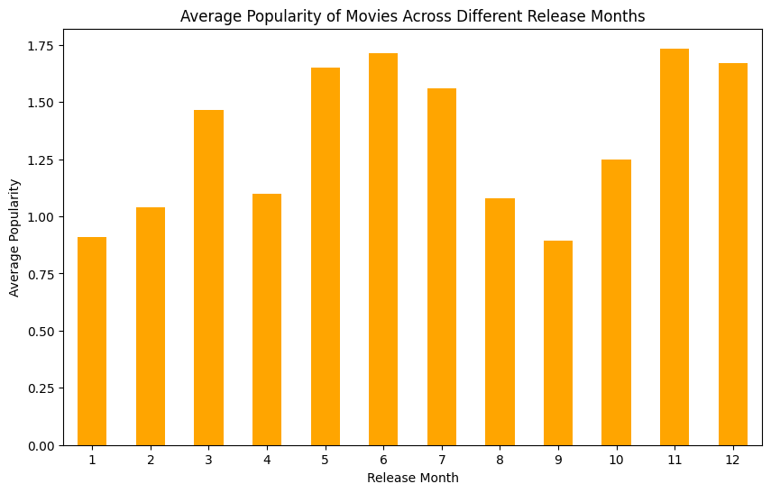

```python
##How do the popularity scores of movies vary across different release months?
# Extract release month from release_date
df['release_month'] = pd.to_datetime(df['release_date']).dt.month

# Calculate average popularity for each release month
monthly_avg_popularity = df.groupby('release_month')['popularity'].mean()

# Plotting the average popularity for different release months
plt.figure(figsize=(10, 6))
monthly_avg_popularity.plot(kind='bar', color='orange')
plt.title('Average Popularity of Movies Across Different Release Months')
plt.xlabel('Release Month')
plt.ylabel('Average Popularity')
plt.xticks(rotation=0)
plt.show()
```

### Question 7: What is the distribution of movie genres?

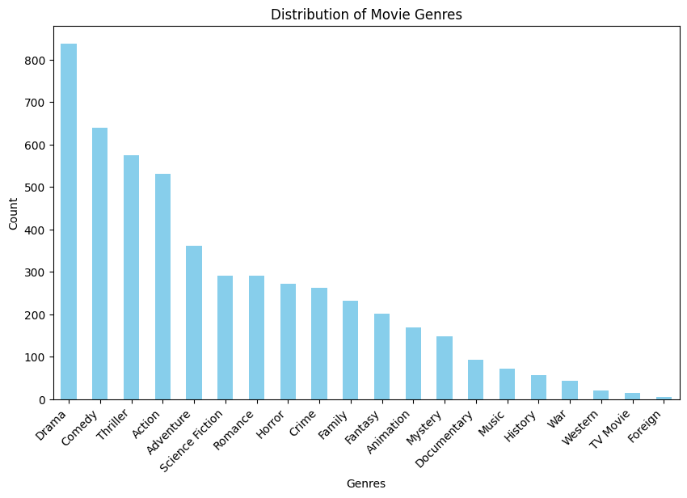

```python
# Splitting genres and counting occurrences
genres = df['genres'].str.split('|', expand=True).stack().value_counts()

# Plotting the distribution of movie genres
plt.figure(figsize=(10, 6))
genres.plot(kind='bar', color='skyblue')
plt.title('Distribution of Movie Genres')
plt.xlabel('Genres')
plt.ylabel('Count')
plt.xticks(rotation=45, ha='right')
plt.show()
```

### Question 8: Is there a correlation between the runtime of movies and their average rating?

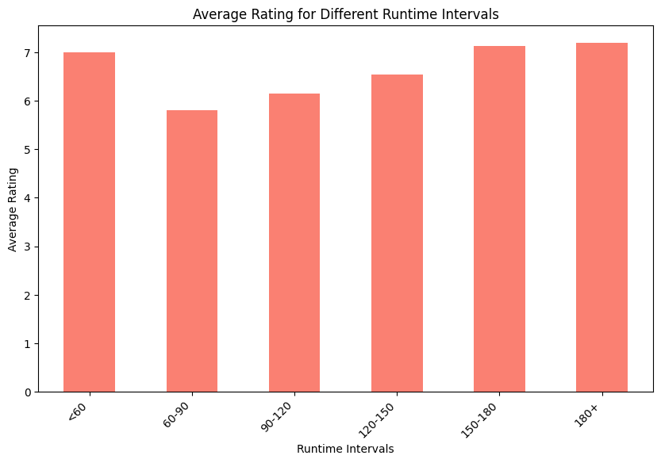

```python
# Create runtime intervals
runtime_intervals = pd.cut(df['runtime'], bins=[0, 60, 90, 120, 150, 180, np.inf], labels=['<60', '60-90', '90-120', '120-150', '150-180', '180+'])

# Calculate average rating for each runtime interval
runtime_rating = df.groupby(runtime_intervals)['vote_average'].mean()

# Plotting the average rating for different runtime intervals
plt.figure(figsize=(10, 6))
runtime_rating.plot(kind='bar', color='salmon')
plt.title('Average Rating for Different Runtime Intervals')
plt.xlabel('Runtime Intervals')
plt.ylabel('Average Rating')
plt.xticks(rotation=45, ha='right')
plt.show()
```

### Question 9: Which production companies generate the highest total revenue for movies?

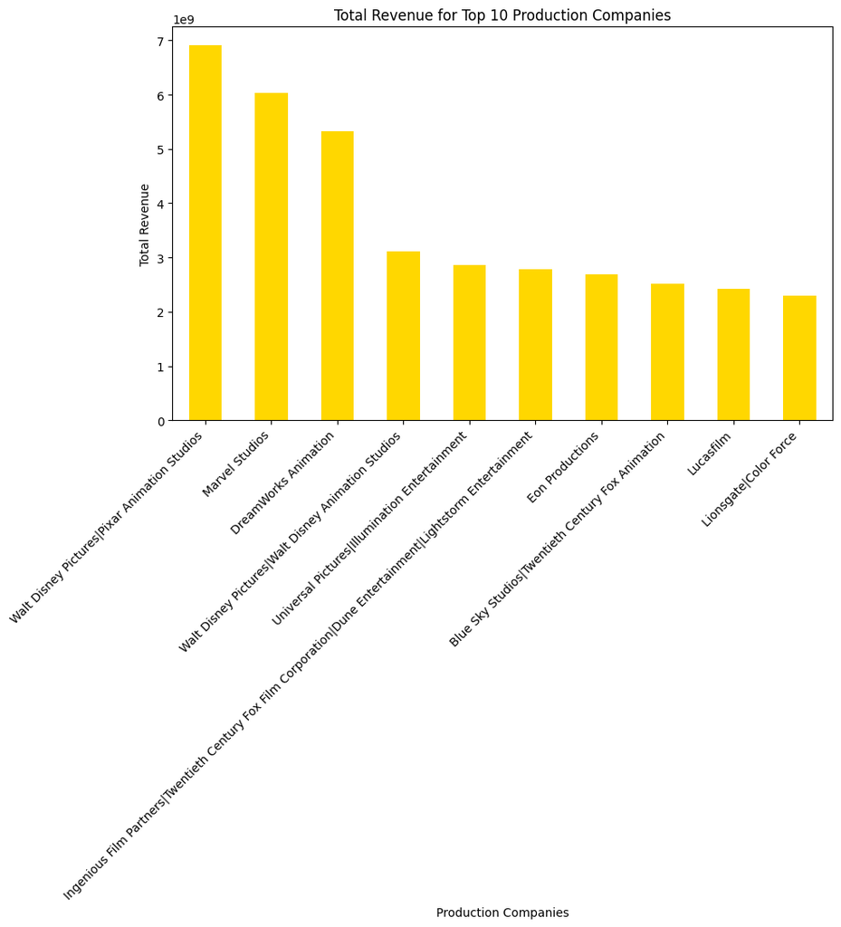

```python
# Calculate total revenue for each production company
production_revenue = df.groupby('production_companies')['revenue'].sum().sort_values(ascending=False).head(10)

# Plotting the total revenue for top 10 production companies
plt.figure(figsize=(10, 6))
production_revenue.plot(kind='bar', color='gold')
plt.title('Total Revenue for Top 10 Production Companies')
plt.xlabel('Production Companies')
plt.ylabel('Total Revenue')
plt.xticks(rotation=45, ha='right')
plt.show()
```

### Question 10: Has the average movie runtime changed over time?

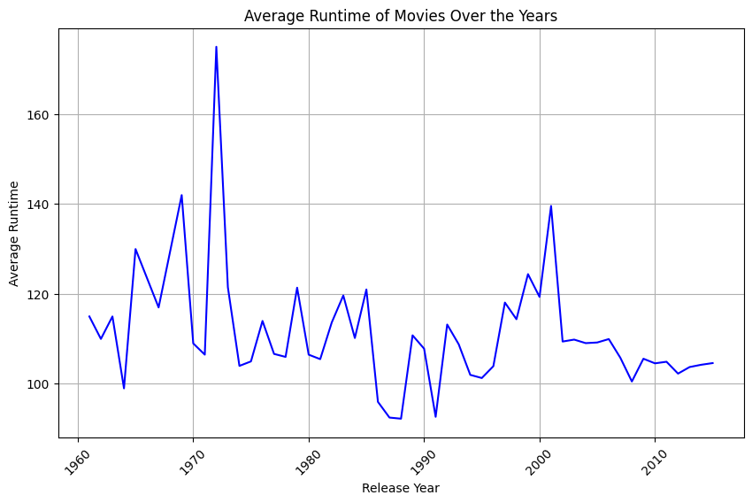

```python
# Calculate average runtime for each year
yearly_avg_runtime = df.groupby('release_year')['runtime'].mean()

# Plotting the average runtime trend over the years
plt.figure(figsize=(10, 6))
yearly_avg_runtime.plot(kind='line', color='blue')
plt.title('Average Runtime of Movies Over the Years')
plt.xlabel('Release Year')
plt.ylabel('Average Runtime')
plt.xticks(rotation=45)
plt.grid(True)
plt.show()
```

### Question 11: How does the average vote average of movies change annually?

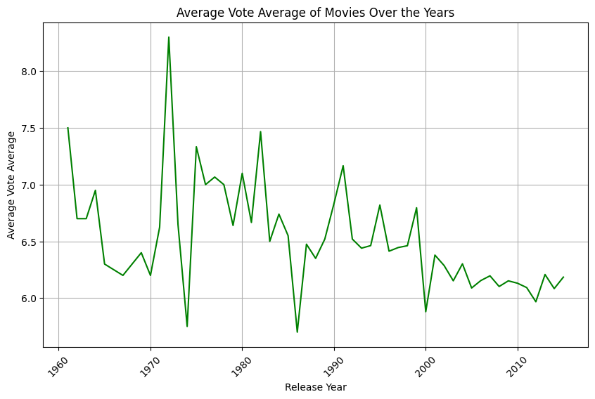

```python
# Calculate average vote average for each year
yearly_avg_vote_average = df.groupby('release_year')['vote_average'].mean()

# Plotting the average vote average trend over the years
plt.figure(figsize=(10, 6))
yearly_avg_vote_average.plot(kind='line', color='green')
plt.title('Average Vote Average of Movies Over the Years')
plt.xlabel('Release Year')
plt.ylabel('Average Vote Average')
plt.xticks(rotation=45)
plt.grid(True)
plt.show()
```

## Conclusions

In conclusion, our exploratory data analysis of the TMDb Movies dataset has provided valuable insights into various aspects of movie properties and their associations. Here are the key findings:

> **1**: Properties Associated with High Revenues: We found that movies with higher budgets tend to generate higher revenues, indicating a positive correlation between budget and revenue. Additionally, popularity and vote average also showed positive correlations with revenue, suggesting that well-received movies tend to perform better financially.

> **2**: Distribution of Adjusted Movie Revenue: The distribution of adjusted movie revenue is right-skewed, with a majority of movies having lower revenues and only a few outliers achieving significantly higher revenues.

> **3**: Correlation between Adjusted Budget and Adjusted Revenue: Our analysis suggests a positive correlation between adjusted budget and adjusted revenue, indicating that higher budget movies tend to generate higher revenues. However, further statistical tests are needed to confirm this relationship.

> **4**: Relationship between Movie Popularity and Adjusted Revenue: There appears to be a positive relationship between movie popularity and adjusted revenue, indicating that popular movies tend to have higher revenues.

> **5**: Trend in Adjusted Revenue Over Release Years: The trend in adjusted revenue over release years shows variations, with some years having higher average revenues than others. This trend could be influenced by various factors such as economic conditions, industry trends, and audience preferences.

## Submitting your Project

> **Tip**: Alternatively, you can download this report as .html via the **File** > **Download as** submenu, and then manually upload it into the workspace directory by clicking on the orange Jupyter icon in the upper left, then using the Upload button.

> **Tip**: Once you've done this, you can submit your project by clicking on the "Submit Project" button in the lower right here. This will create and submit a zip file with this .ipynb doc and the .html or .pdf version you created. Congratulations!

```python
# Running this cell will execute a bash command to convert this notebook to an .html file
!python -m nbconvert --to html Investigate_a_Dataset.ipynb
```